# Homework 4 - Partitioning Variability

Engineering Statistics I (MA223)

## Problem 1 (Alfalfa)

Large state universities, such as Purdue for example, had their origins in improving the local agricultural community. As a result, many of these universities continue research with connections to the local economy. A researcher at the University of Wisconsin is interested in determining whether there is evidence that the yield (in bushels), on average, of Alfalfa differs across six varieties. Such research is conducted to aid farmers in determining which varieties should be planted to produce the largest crop in a particular season (in which drought or disease may be of particular concern). The data is available on the course site (`Alfalfa`).

The following code reads in the data and names the resulting dataset `alfalfa`.

```r
alfalfa <- read_csv("Alfalfa.csv")
```

### Part (a)

State the null and alternative hypotheses that capture the question of interest of the researcher.

### Part (b)

Provide a graphic of the data which is helpful for comparing the yield of various Alfalfa varieties. Tip: side-by-side plots are helpful when you have more than a few groups; however, a boxplot should be reserved for when you have larger sample sizes.

### Part (c)

Based on the figure in part (b), would you expect the standardized test statistic computed with this data to be large are small? Explain.

### Part (d)

Based on your answer in part (c), would you expect a small p-value or a large p-value? Explain.

### Part (e)

Suppose that for the above data, the p-value is less than 0.01. The farmer concludes “we have evidence that each variety of alfalfa results in a different yield, on average.” Explain why this statement is incorrect.

## Problem 2 (Mice Anxiety)

Researchers from the Institute for Behavioral Genetics at the University of Colorado were interested in investigating the effect that the enzyme protein kinase C (PKC) has on anxiety in mice. The genotype for a particular gene in a mouse (or human) consists of two alleles (copies) of each chromosome, one each from of the father and mother. The investigators in the study randomly selected 15 mice from three groups:

- Group A: nether of he mouse alleles for PKC produced an enzyme.
- Group B: one of the two alleles for PKC produced an enzyme and the other did not.
- Group C: both PKC alleles produced the enzyme.

To measure the anxiety in the mice, scientists measured the time (in seconds) the mice spent in the “open-ended” sections of an elevated maze. Mice that spend more time in open-ended sections exhibit decreased anxiety. To establish the effect of PKC on anxiety, the researchers want to determine if the average amount of time mice spend in the open-ended section of the maze differs between the PKC groups.

The data is available to download from the course site (`MiceAnxiety`). The following code reads in the data and calls it the data `mice`.

```r
mice <- read_csv("MiceAnxiety.csv")
```

## Part (a)

Which of the following aspects of a well-designed study *was* implemented in this study?

1. Random sampling of subjects.
2. Random assignment of subjects to groups.
3. Replication to measure subject-to-subject variability.
4. Answers A and B only.
5. Answers A and C only.
6. Answers B and C only.
7. Answers A, B and C.
8. None of the above.

No justification needed.

## Part (b)

State the null and alternative hypotheses which capture the question of interest.

## Part (c)

Construct an appropriate graphic summarizing the data to help address the question of interest.

### Part (d)

The standardized test statistic corresponding to the hypotheses stated in part (b) using the sample provided is 10.91. The following graphic illustrates a model for the null distribution of this standardized test statistic. Based on the model, which of the following is most likely the p-value for this analysis?

1. $<$ 0.001
2. 0.100
3. 0.500
4. 0.900
5. $>$ 0.999

No justification required.

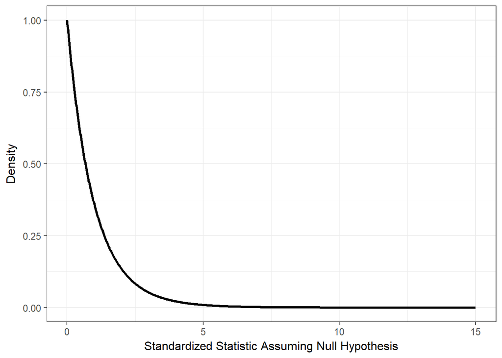

Model of the null distribution of the standardized statistic for this study.

### Part (e)

What conclusion can the researchers make regarding their question of interest given the data available? Explain.